# Chapter 3 — Probabilities and Hypothesis Testing (R companion)

R/tidyverse translation of *Understanding Data by Alan Garfinkel and Yina Guo

Adrian Soto-Mota, MD, PhD, FACP.

2026-04-24

# Orientation

Chapter 3 (book pp. 103–152) introduces **simulation-based NHST**: instead of invoking a theoretical distribution, we construct the null world by computer and see how extreme our observation is in that world. The book contains **no Python code listings** in this chapter. This companion builds the machinery from loops (transparent, slow) up to vectorized R (fast, idiomatic).

# §3.1 — Modeling and simulating probabilities *(book p. 103)*

## A fair coin

```r
# Simulate 1 toss: rbinom(n_experiments, size = n_tosses_per_experiment, prob)
rbinom(10, size = 1, prob = 0.5)          # 10 individual tosses, 0 = tails
```

```
##  [1] 1 1 0 1 1 1 1 0 1 1
```

```r
# Simulate 1000 experiments of 10 tosses each, count heads in each
heads <- rbinom(1000, size = 10, prob = 0.5)
table(heads)
```

```
## heads
##   0   1   2   3   4   5   6   7   8   9
##   2  13  41 139 196 254 187 120  41   7
```

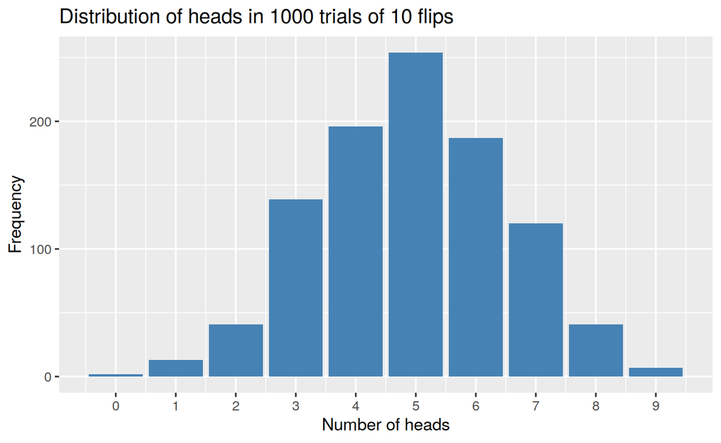

```r
tibble(heads = heads) |>
  ggplot(aes(heads)) +
  geom_bar(fill = "steelblue") +
  scale_x_continuous(breaks = 0:10) +
  labs(title = "Distribution of heads in 1000 trials of 10 flips",
       x = "Number of heads", y = "Frequency")
```

## Rolling dice

```r
# Sample uniformly from {1..6}, with replacement, 10,000 times
rolls <- sample(1:6, size = 10000, replace = TRUE)
prop.table(table(rolls))   # empirical probabilities converge to 1/6
```

```
## rolls
##      1      2      3      4      5      6
## 0.1671 0.1724 0.1670 0.1686 0.1699 0.1550
```

# §3.2 — Null Hypothesis Significance Testing by simulation *(book p. 112)*

## The setup

Suppose we observe 7 heads out of 10 tosses of a coin. Is it “loaded”?

```r
observed_heads <- 7
n_tosses       <- 10
```

The null hypothesis: **the coin is fair**, `p = 0.5`.

## Simulate the null world

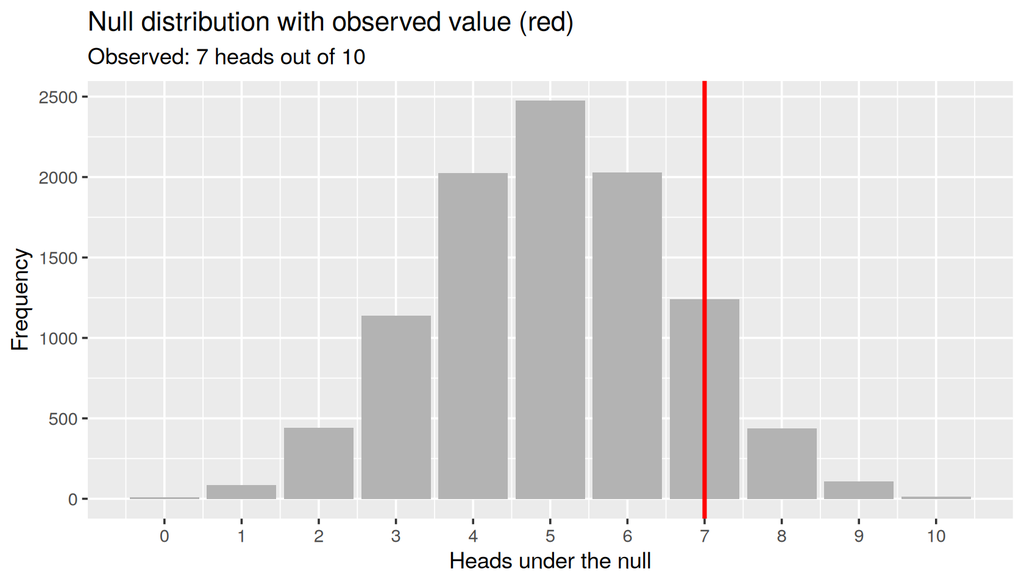

```r
# Faithful loop version — this is what a pedagogical translation looks like
n_sim <- 10000
null_heads <- numeric(n_sim)
for (i in seq_len(n_sim)) {
  tosses <- sample(c("H", "T"), size = n_tosses, replace = TRUE)
  null_heads[i] <- sum(tosses == "H")
}

# Equivalent idiomatic R (much faster):
# null_heads <- rbinom(n_sim, size = n_tosses, prob = 0.5)

tibble(heads = null_heads) |>
  ggplot(aes(heads)) +
  geom_bar(fill = "grey70") +
  geom_vline(xintercept = observed_heads, color = "red", linewidth = 1) +
  scale_x_continuous(breaks = 0:10) +
  labs(title = "Null distribution with observed value (red)",
       subtitle = paste("Observed:", observed_heads, "heads out of", n_tosses),
       x = "Heads under the null", y = "Frequency")
```

## Compute the p-value

```r
# Two-sided p-value: "at least as extreme" in either direction.
# "As extreme" here means |heads − 5| >= |7 − 5| = 2
observed_distance <- abs(observed_heads - n_tosses/2)
p_value <- mean(abs(null_heads - n_tosses/2) >= observed_distance)
p_value
```

```
## [1] 0.3473
```

This matches what `binom.test()` gives us analytically:

```r
binom.test(x = observed_heads, n = n_tosses, p = 0.5)$p.value
```

```
## [1] 0.34375
```

## Surprise value *(book §3.2, p. 117)*

The chapter introduces **surprise** `S = -log₂(p)` — the number of bits of evidence against the null. It puts tiny p-values on a more intuitive scale: `p = 0.05` → S ≈ 4.3 bits; `p = 0.001` → S ≈ 10 bits.

```r
surprise <- function(p) -log2(p)
tibble(
  p  = c(0.5, 0.1, 0.05, 0.01, 0.001, 1e-6),
  S_bits = surprise(p)
)
```

```
## # A tibble: 6 x 2
##          p S_bits
##      <dbl>  <dbl>
## 1 0.5        1
## 2 0.1        3.32
## 3 0.05       4.32
## 4 0.01       6.64
## 5 0.001      9.97
## 6 0.000001  19.9
```

# §3.2 — Factors that influence the p-value *(book p. 125)*

Three knobs control how small a p-value you get:

1. **Effect size** — how far the true `p_coin` is from 0.5.
2. **Sample size** — `n_tosses`.
3. **Noise** — the inherent variability.

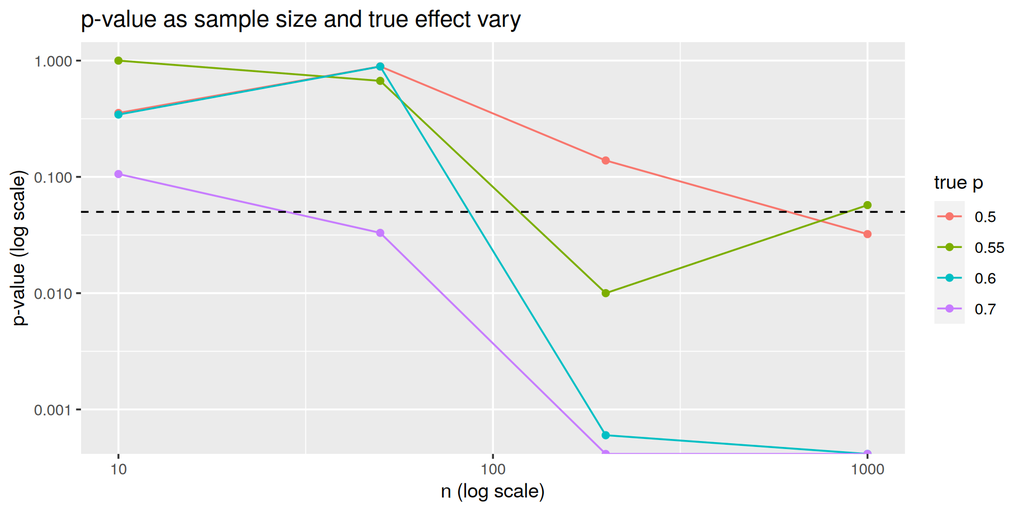

```r
simulate_p <- function(n_tosses, true_p, n_sim = 5000) {
  null_heads     <- rbinom(n_sim, size = n_tosses, prob = 0.5)   # null world
  observed_heads <- rbinom(1,     size = n_tosses, prob = true_p) # one "real" expt
  obs_dist <- abs(observed_heads - n_tosses/2)
  mean(abs(null_heads - n_tosses/2) >= obs_dist)
}

grid <- expand_grid(
  n_tosses = c(10, 50, 200, 1000),
  true_p   = c(0.50, 0.55, 0.60, 0.70)
) |>
  rowwise() |>
  mutate(p_value = simulate_p(n_tosses, true_p)) |>
  ungroup()

ggplot(grid, aes(n_tosses, p_value, color = factor(true_p))) +
  geom_line() + geom_point() +
  geom_hline(yintercept = 0.05, linetype = "dashed") +
  scale_x_log10() + scale_y_log10() +
  labs(title = "p-value as sample size and true effect vary",
       x = "n (log scale)", y = "p-value (log scale)",
       color = "true p")
```

# §3.3 — What’s wrong with NHST? *(book p. 132)*

Reproduce the chapter’s critiques:

## (a) α = 0.05 is too lax *(book §3.3, p. 132)*

```r
# If 100 studies per year test true nulls at α = 0.05,
# we expect about 5 "significant" false alarms every year.
# Across a whole literature, the false discovery rate is large.

# Across many experiments, the fraction of false positives at the chosen α is α.
n_exp <- 5000
alphas <- c(0.05, 0.01, 0.001)
p_values <- replicate(n_exp, {
  # True null: x ~ N(0,1), test H0: mean = 0
  x <- rnorm(30)
  t.test(x, mu = 0)$p.value
})
map_dbl(alphas, \(a) mean(p_values < a))
```

```
## [1] 0.0490 0.0096 0.0008
```

## (b) Confidence intervals are more informative *(book §3.3, p. 142)*

```r
x <- rnorm(30, mean = 0.2, sd = 1)
t.test(x, mu = 0)$p.value         # Just a yes/no
```

```
## [1] 0.02800809
```

```r
t.test(x, mu = 0)$conf.int        # Tells us the plausible range of the true mean
```

```
## [1] 0.04455293 0.72485657
## attr(,"conf.level")
## [1] 0.95
```

A CI of, say, `[-0.05, 0.55]` is far more informative than “p = 0.07 (not significant)”.

## (c) p is not P(H0 | data) *(book §3.3 “The p-value is the answer to the wrong question”, p. 143)*

This is Chapter 12’s full topic, but here’s the preview:

```r
# p-value answers: "If H0 were true, how often would we see data this extreme?"
# It does NOT answer: "Given these data, how likely is H0?"
# The second question requires Bayes' theorem and a prior probability.
```

# Exercises

1. Repeat the 7-out-of-10 analysis with observed = 70 out of 100. Is the p-value the same? Why not?
2. Flip the surprise formula. What p corresponds to “1 bit of evidence”? “20 bits”?
3. Using the `simulate_p()` function, find the smallest `n_tosses` at which a true `p_coin = 0.55` gives a p-value below 0.01 about 80 % of the time. (This is a power calculation, previewed for Chapter 11.)